```python
# Author: Emilie Helen Wolf
# Created: September 21, 2021
# This is the statistical analysis notebook for the E-news Express project in the DSBA course
# This notebook demonstrates knowledge of hypothesis testing and statistical inference
```

# Background

Suppose you are hired as a Data Scientist in E-news Express. The design team of the company has created a new landing page. You have been assigned the task to decide whether the new landing page is more effective to gather new subscribers. Suppose you randomly selected 100 users and divided them equally into two groups. The old landing page is served to the first group (control group) and the new landing page is served to the second group (treatment group).

# Dataset File

abtest.csv

# Dataset Columns

1. **user_id** - This represents the user ID of the person visiting the website.
2. **group** - This represents whether the user belongs to the first group (control) or the second group (treatment).
3. **landing_page** - This represents whether the landing page is new or old.
4. **time_spent_on_the_page** - This represents the time (in minutes) spent by the user on the landing page.
5. **converted** - This represents whether the user gets converted to a subscriber of the news portal or not.
6. **language_preferred** - This represents the language chosen by the user to view the landing page.

# Questions

### 1. What's the result of exploratory data analysis?

- Describe the initial dataset
- Plot the univariate distributions and describe them
- Plot the multivariate correlations and describe them

### 2. Do the users spend more time on the new landing page than the old landing page?

- Satisfy Normal distributions?
- Satisfy Equal variances/standard deviations?
- Two Independent Sample T-test for Equality of Means - Equal Std Dev
- One-Tailed
- `ttest_ind()`

### 3. Is the conversion rate for the new page greater than the conversion rate for the old page?

- Binomial
- Two Proportion Z Test
- One-Tailed
- `proportions_ztest()`

### 4. Does the converted status depend on the preferred language?

- Setup contingency table with `pd.crosstab()`
- Chi Square Test for Independence
- `chi2_contingency()`

### 5. Is the mean time spent on the new page same for the different language users?

- check for normal distributions `shapiro()`
- check for equal variances `levene()`
- One Way ANOVA test
- `f_oneway()`

### *Consider a significance level of 0.05 (5%) for all tests

# First Look

```python
# import packages
import numpy as np
import pandas as pd
import matplotlib.pyplot as plt
import seaborn as sns
import scipy.stats as stats
from statsmodels.stats.proportion import proportions_ztest

# make plots look nicer
sns.set_style("darkgrid")
sns.set_context("poster")

# import the dataframe and display first 5 rows
df = pd.read_csv('abtest.csv')
df.head()
```

|  | user_id | group | landing_page | time_spent_on_the_page | converted | language_preferred |
| --- | --- | --- | --- | --- | --- | --- |
| 0 | 546592 | control | old | 3.48 | no | Spanish |
| 1 | 546468 | treatment | new | 7.13 | yes | English |
| 2 | 546462 | treatment | new | 4.40 | no | Spanish |
| 3 | 546567 | control | old | 3.02 | no | French |
| 4 | 546459 | treatment | new | 4.75 | yes | Spanish |

```python
# What's the file size, shape, datatypes, and null count?
df.info()
```

```
<class 'pandas.core.frame.DataFrame'>
RangeIndex: 100 entries, 0 to 99
Data columns (total 6 columns):
 #   Column                  Non-Null Count  Dtype
---  ------                  --------------  -----
 0   user_id                 100 non-null    int64
 1   group                   100 non-null    object
 2   landing_page            100 non-null    object
 3   time_spent_on_the_page  100 non-null    float64
 4   converted               100 non-null    object
 5   language_preferred      100 non-null    object
dtypes: float64(1), int64(1), object(4)
memory usage: 4.8+ KB
```

```python
# Does the amount of unique values in each category seem normal?
df.nunique()
```

```
user_id                   100
group                       2
landing_page                2
time_spent_on_the_page     94
converted                   2
language_preferred          3
dtype: int64
```

```python
# Check that there are 50 samples in each group
df['group'].value_counts()
```

```
treatment    50
control      50
Name: group, dtype: int64
```

```python
df['landing_page'].value_counts()
```

```
new    50
old    50
Name: landing_page, dtype: int64
```

```python
# Create two subset dataframes, one for control and one for treatment

old = df.loc[df['landing_page']=='old'].copy()
new = df.loc[df['landing_page']=='new'].copy()

# Check the sample distributions of language preferred
new['language_preferred'].value_counts()
```

```
Spanish    17
French     17
English    16
Name: language_preferred, dtype: int64
```

```python
old['language_preferred'].value_counts()
```

```
Spanish    17
French     17
English    16
Name: language_preferred, dtype: int64
```

# Observations

- No missing data
- We have 1 continuous variable (time spent on page) and 4 discrete variables (converted, language, landing page, group)
- The control group and the treatment group are equal in size (50).
- Each group also has an equal distribution for the language preferred (French 17, Spanish 17, English 16).
- All 100 randomly selected users have unique user IDs
- Data is tidy and no manipulations needed other than splitting the two groups

# Exploratory Data Analysis

### What's the distribution of `time_spent_on_the_page` for both groups combined?

```
count    100.000000
mean       5.377800
std        2.378166
min        0.190000
25%        3.880000
50%        5.415000
75%        7.022500
max       10.710000
Name: time_spent_on_the_page, dtype: float64
```

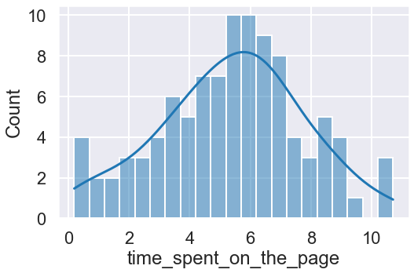

```python
# Print the numerical summary of all the times
print(df['time_spent_on_the_page'].describe())

# Set the size of the plot
plt.figure(figsize=(8,5))

# Create a histogram with a density curve
sns.histplot(data=df, x='time_spent_on_the_page', kde=True, bins=21);
```

### What's the distribution of `time_spent_on_the_page` for each group?

```
Old page had a mean time of 4.5 minutes with a standard deviation of 2.6 minutes.
New page had a mean time of 6.2 minutes with a standard deviation of 1.8 minutes.
```

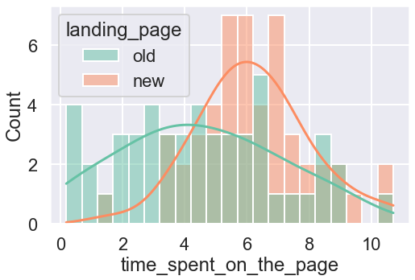

```python
# Print the mean and standard deviations of the times for both landing pages
print("Old page had a mean time of",
      round(old['time_spent_on_the_page'].mean(),1),"minutes with a standard deviation of",
      round(old['time_spent_on_the_page'].std(),1),"minutes.")

print("New page had a mean time of",
      round(new['time_spent_on_the_page'].mean(),1),"minutes with a standard deviation of",
      round(new['time_spent_on_the_page'].std(),1),"minutes.")

# Plot a histogram of the times for both landing pages
plt.figure(figsize=(8,5))
sns.histplot(data=df, x='time_spent_on_the_page', palette="Set2", hue='landing_page', kde=True, bins=21);

# Save the figure to the harddrive
plt.savefig("time_by_page.jpg", bbox_inches='tight')
```

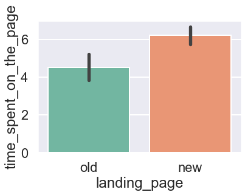

```python
# Create a simple bar plot for the average time spent on each page
sns.barplot(data=df, x='landing_page', y='time_spent_on_the_page', palette='Set2');
plt.savefig("time_bar_page.jpg", bbox_inches='tight')
```

# Observations

- The distributions of `time_spent_on_the_page` in both graphs above look symmetrical with two tails like a **Normal Curve.**
- There is a wider spread of times on the old page
- There is a narrower spread of times on the new page

### What's the `converted` rates in both groups?

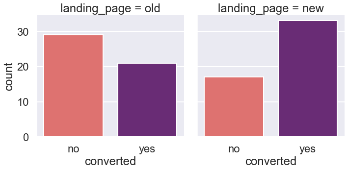

```python
# Create a count plot of the converted status
sns.catplot(data=df, x='converted', col='landing_page', palette='magma_r', kind='count');
```

```python
# Find the conversion rates
print(old[['converted']].value_counts(normalize=True))
print(new[['converted']].value_counts(normalize=True))
```

```
converted
no           0.58
yes          0.42
dtype: float64
converted
yes          0.66
no           0.34
dtype: float64
```

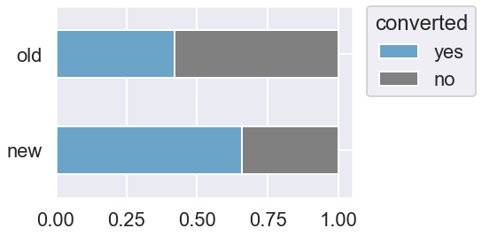

```python
# Create a new dataframe based on the conversion rates
yes = [.66, .42]
no = [.34, .58]
index = ['new', 'old']
dfc = pd.DataFrame({'yes': yes, 'no': no}, index=index)

# Plot a stacked horizontal bar chart to better vizualize percentages
ax = dfc.plot.barh(stacked=True,color={"yes": "#6aa4c8", "no": "gray"})

# Move the legend to the outside
plt.legend(bbox_to_anchor=(1.05, 1), loc='upper left', borderaxespad=0, title="converted");
plt.savefig("barh.jpg", bbox_inches='tight')
```

### What's the conversion rate of the old landing page?

```python
# Subset the converted column
# Calculate the percentages of yes's and no's using value_counts() and normalize
# Finally, extract the value for yes's
old_c_rate = old[['converted']].value_counts(normalize=True).loc["yes"][0]
old_c_rate
```

```
0.42
```

### What's the conversion rate of the new landing page?

```python
new_c_rate = new[['converted']].value_counts(normalize=True).loc["yes"][0]
new_c_rate
```

```
0.66
```

### How do these rates compare?

```python
new_c_rate/old_c_rate
```

```
1.5714285714285716
```

# Observations

- There are about 57% more conversions on the new page than the old page.

### What's the `converted` rate by `language_preferred`?

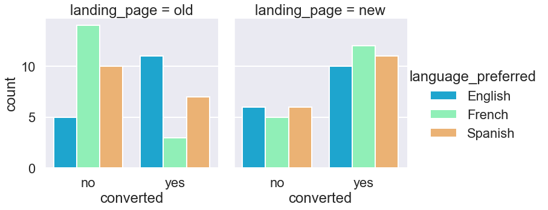

```python
# Count plot
sns.catplot(data=df, x='converted', col='landing_page',
            hue='language_preferred', kind='count', palette='rainbow', hue_order=['English','French','Spanish']);
plt.savefig("language_convert_count.jpg", bbox_inches='tight')
```

# Observations

- The rate of conversion on the old page is highest for English and lowest for French.
- The rate of conversion on the new page is fairly even across all languages.
  - Is the new landing page appealing to more languages than the old landing page?

### How did the `converted` rate differ among `language_preferred`?

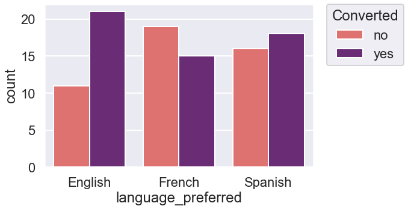

```python
# Count plot

plt.figure(figsize=(8,5))
sns.countplot(data = df,
             x='language_preferred',
             hue='converted',
             palette='magma_r',
             order=['English','French','Spanish'])
plt.legend(bbox_to_anchor=(1.05, 1), loc='upper left', borderaxespad=0, title="Converted");
plt.savefig("language_convert_count_full.jpg", bbox_inches='tight')
```

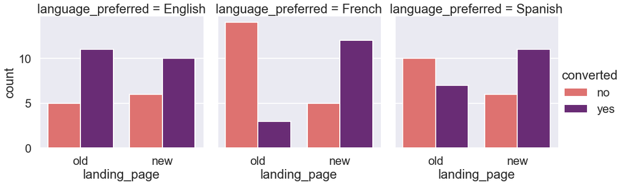

```python
# Another categorical count plot
sns.catplot(data=df, hue='converted', x='landing_page',
            col='language_preferred', kind='count',palette='magma_r',
           col_order=['English','French','Spanish']);
plt.savefig("language_conversion_count.jpg", bbox_inches='tight')
```

# Observations

- The conversion rate of English readers was nearly the same in both the control and the treatment group
- The conversion rate of French readers was much greater in the treatment group
- The conversion rate of Spanish readers was somewhat greater in the treatment group

### Is there a correlation between `time_spent_on_the_page` and `converted`?

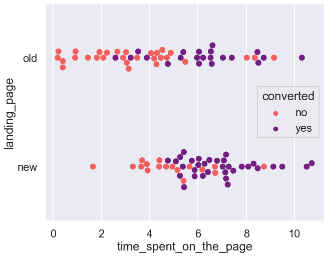

```python
# Create a swarm plot to vizualize spread and distribution

plt.figure(figsize=(10,8))
sns.swarmplot(y = "landing_page", x = "time_spent_on_the_page",
              hue = "converted", palette='magma_r', orient = "h", data = df, s=12);
plt.savefig("time_by_converted.jpg", bbox_inches='tight')
```

# Observations

- In both groups, most conversions came from users who spent more time on the page.
- In general, users spent more time on the new page than the old.

### Is there a correlation between `time_spent_on_the_page` and `language_preferred`?

```
Standard deviation of time by Spanish preferred: 1.8
Standard deviation of time by English preferred: 2.6
Standard deviation of time by French preferred: 2.7
```

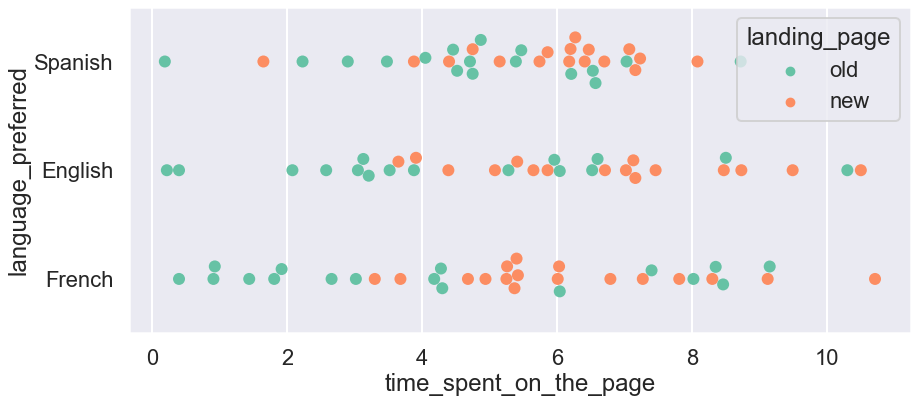

```python
# Print the standard deviation of time for each language
print("Standard deviation of time by Spanish preferred:",
      round(df.loc[df['language_preferred']=='Spanish']['time_spent_on_the_page'].std(),1))
print("Standard deviation of time by English preferred:",
      round(df.loc[df['language_preferred']=='English']['time_spent_on_the_page'].std(),1))
print("Standard deviation of time by French preferred:",
      round(df.loc[df['language_preferred']=='French']['time_spent_on_the_page'].std(),1))

# Swarm plot to show spread of times by language
plt.figure(figsize=(14,6))
sns.swarmplot(x = "time_spent_on_the_page",
              y = "language_preferred",
              orient = "h",
              data = df,
              palette = 'Set2',
              hue='landing_page',
              s=12);
```

# Observations

- There does not seem to be a correlation between `time_spent_on_the_page` and `language_preferred`
- The times of each language seem to be similarly distributed with Spanish having a slightly more narrow spread
- As we saw before, most of the longer times are found on the new landing page

### For each group, what's the average `time_spent_on_the_page` by `language_preferred`?

```
English users spent an averge of 6.7 minutes on the new page.
French users spent an averge of 6.2 minutes on the new page.
Spanish users spent an averge of 5.8 minutes on the new page.
```

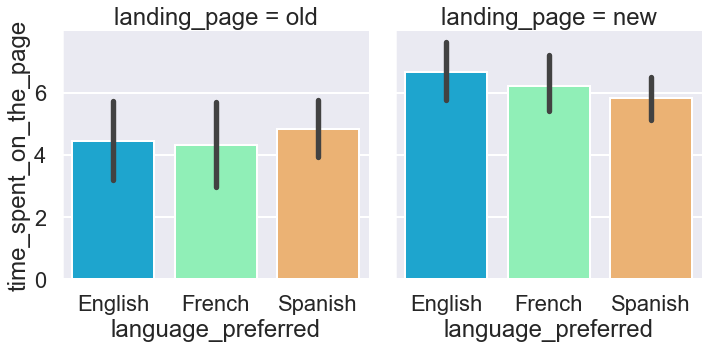

```python
# Categorical bar plot
sns.catplot(data=df, col='landing_page', y='time_spent_on_the_page', x='language_preferred',
            kind='bar',
            palette='rainbow',
            order=['English','French','Spanish']
            )

plt.savefig("time_by_converted.jpg", bbox_inches='tight')

# Print the average times spent on the new page by language
print("English users spent an averge of",
      round(new[new['language_preferred']=='English']['time_spent_on_the_page'].mean(),1),
      "minutes on the new page.")
print("French users spent an averge of",
      round(new[new['language_preferred']=='French']['time_spent_on_the_page'].mean(),1),
      "minutes on the new page.")
print("Spanish users spent an averge of",
      round(new[new['language_preferred']=='Spanish']['time_spent_on_the_page'].mean(),1),
      "minutes on the new page.")
```

# Observations:

- The average times spent on the page were even across all languages in both groups

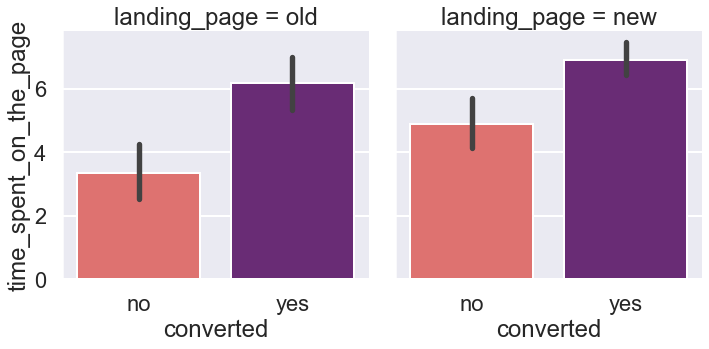

```python
# Categorical bar plot to vizualize average time of converted on each page
sns.catplot(data=df, x='converted', y='time_spent_on_the_page',
            col='landing_page',
            kind='bar',
            palette = 'magma_r');
```

### For each group, what's the average `time_spent_on_the_page` by `language_preferred` and `converted`?

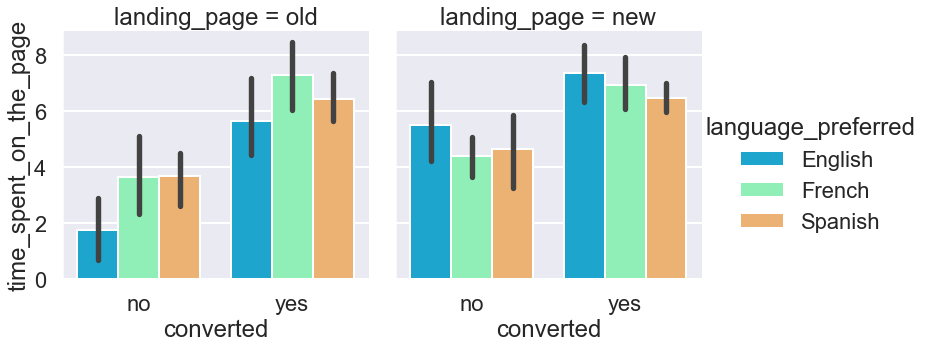

```python
# Categorical bar plot
sns.catplot(data=df, x='converted', y='time_spent_on_the_page',
            col='landing_page',
            hue='language_preferred',
            hue_order=['English','French','Spanish'],
            kind='bar',
            palette = 'rainbow');
plt.savefig("time_.jpg", bbox_inches='tight')
```

# Observations

- More time was spent on the new page overall, even by those who did not convert.
- On the old landing page, English readers spent less time than the other languages
- On the new landing page, English readers spent more time than the others on the new page

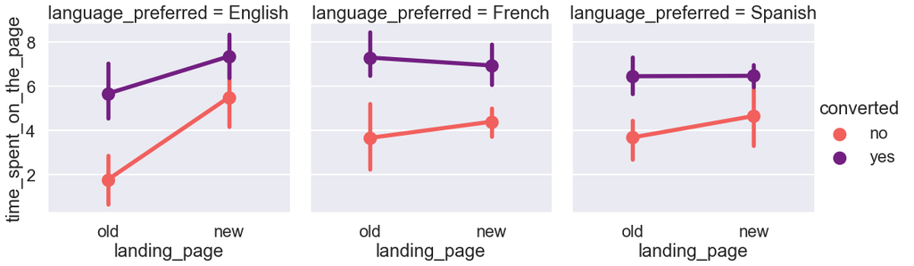

```python
# Categorical point plot to show differences between groups
sns.catplot(data=df,
            hue='converted',
            y='time_spent_on_the_page',
            col='language_preferred',
            x='landing_page',
            kind='point',
            col_order=['English','French','Spanish'],
            palette = 'magma_r');

plt.savefig("pointplot.jpg", bbox_inches='tight')
```

# Observations

- In all 3 languages, in both groups, those who converted spent more time on the page than those who did not convert.
- French and Spanish had similar mean times in both groups, whereas English had much longer times in the treatment group.

# Question: Do the users spend more time on the new landing page than the old landing page?

We already determined through exploratory data analysis that, on average, users spend more time on the new landing page than the old landing page, but what is the probability that this increase in time is not because of random chance?

### Null and Alternate Hypotheses for Testing Equality of Means

We will test the null hypothesis

> $H_0:\mu_n=\mu_o$

against the alternate hypothesis

> $H_a:\mu_n>\mu_o$

### Check the assumptions

- The data being tested is continous (`time_spent_on_the_page`)
- The data being tested seems to be normally distributed
- The two samples being tested are independent
- The data was collected randomly from the population
- The standard deviations of the samples are close enough to be assumed equal
  - 2.6 is not more than 2 times 1.8
- This is a one-tailed test

### Therefore we will use the Two Independent Sample T-test `ttest_ind()`

```python
test_stat, p_value = stats.ttest_ind(
    new['time_spent_on_the_page'],       # treatment
    old['time_spent_on_the_page'],       # control
    equal_var = True,                    # equal by assumption
    alternative = 'greater')             # greater because this is a one-tailed test
print('The p-value is ' + str(p_value))
```

```
The p-value is 0.0001316123528095005
```

# Observations

The probability that these 2 samples came from populations with equal means is 0.01%. Since this is well below our confidence level of 5%, we reject the null hypothesis.

#### Thus, we can say with 95% confidence that the time spent on the new landing page is greater than the time spent on the old page.

# Question: Is the conversion rate for the new page greater than the conversion rate for the old page?

We already determined through exploratory data analysis that the conversion rate for the new page was greather, but is this statistically significant? Do we have enough data from our samples to say the increase in conversions is not due to random chance?

### Null and Alternate Hypotheses for Testing Equality of Proportions

We will test the null hypothesis

> $H_0:p_n =p_o$

against the alternate hypothesis

> $H_a:p_n > p_o$

### Check the assumptions

- The data being tested is discrete (`converted`)
- The data is binomial (yes or no)
- The binomial distribution can be approximated to the Normal distribution because of the Central Limit Theorem
- The two samples being tested are independent
- The data was collected randomly from the population
- The samples are greater than 30 (n=50)
- The proportion values within those samples are greather than 10
- This is a one-tailed test

### Therefore we will use the Two Proportion Z Test `proportions_ztest()`

```python
# set the counts of successful conversions [new, old]
yes_count = np.array([33, 21])

# set the sample sizes
n = np.array([50, 50])

# find the p-value, set alternative to larger because this is a one-sided test
test_stat, p_value = proportions_ztest(yes_count, n, alternative='larger')
print('The p-value is ' + str(p_value))
```

```
The p-value is 0.008026308204056278
```